# Bike Share Case Study

Bret Wiebe

2022-06-30

This is the case study project I did as the final component of the *Google Data Analytics Professional Certificate* program (offered online by Coursera). The scenario is fictitious but the data used is real.

### Background Information

Student groups at the post-secondary schools in Winnipeg are planning on developing a proposal for creating a bike sharing operation. They need information about how bike sharing can work in a northern prairie climate and have identified [Great Rides Bike Share](https://greatrides.bcycle.com/) in Fargo, ND as the example operation to be analyzed.

The students are interested in any trends that can be found in the data that indicate that a bike sharing operation could succeed in Winnipeg and that could provide the basis for creating a detailed presentation to stakeholders (potential funders/sponsors). The most recent data available is for 2017.

### Data Sources

The primary source of data is the Great Rides Bike Share website. https://greatrides.bcycle.com/about/data

### Data Cleaning

I uploaded the file **season-data-2017.csv** to Google Sheets. Duplicate rows were removed and a column was added for the number of days of each ride. Two spreadsheets were then created and saved as .csv files: one for multi-day rides and one for same-day rides. These spreadsheets (**sd17_multiday.csv** and **sd17_sameday.csv**) were uploaded to RStudio Cloud for analysis.

### Data Analysis

**RStudio Cloud Preparation**

Installed and loaded packages

```
install.packages("dplyr")
install.packages("tidyr")
install.packages("readr")
install.packages("ggplot2")
library("dplyr")
library("tidyr")
library("readr")
library("ggplot2")
```

**Loaded data into RStudio Cloud**

```
multi_day <- read.csv("bike_data_17/sd17_multiday.csv", stringsAsFactors = FALSE)

same_day <- read.csv("bike_data_17/sd17_sameday.csv", stringsAsFactors = FALSE)
```

**Added columns for day of week and month (values formatted as a number)**

```
dates_numbered_multi_day <- mutate(
  multi_day,
  day_number = format(as.Date(Checkout.Date),"%w"),
  month_number = format(as.Date(Checkout.Date),"%m")

dates_numbered_same_day <- mutate(
  same_day,
  day_number = format(as.Date(Checkout.Date),"%w"),
  month_number = format(as.Date(Checkout.Date),"%m")
```

**Counted rides by each rider type per day of week as number**

```
day_count_riders_multi <- dates_numbered_multi_day %>%
  count(Rider.Type, day_number)

day_count_riders_same <- dates_numbered_same_day %>%
  count(Rider.Type, day_number)
```

**Counted rides by each rider type per month as number**

```
month_count_riders_multi <- dates_numbered_multi_day %>%
  count(Rider.Type, month_number)

month_count_riders_same <- dates_numbered_same_day %>%
  count(Rider.Type, month_number)
```

**Counted total rides by rider type**

```r
multi_day %>% count(Rider.Type)
```

```
##   Rider.Type   n
## 1      Guest  52
## 2     Member   8
## 3    Student 577
```

```r
same_day %>% count(Rider.Type)
```

```
##   Rider.Type     n
## 1      Guest  3371
## 2     Member  1553
## 3    Student 94517
```

**Total rides calculations**

- Total rides for 2017: 52+8+577+3371+1553+94517 = 100078
- Total Guest rides for 2017: 52+3371 = 3423
- Total Member rides for 2017: 8+1553 = 1561
- Total Student rides for 2017: 577+94517 = 95094
- Total Multi-day rides for 2017: 52+8+577 = 637
- Total Same-day rides for 2017: 3371+1553+94517 = 99441

**2017 total rides (percentages)**

- Guest rides : 3423/100078*100 = 3.4 %
- Member rides : 1561/100078*100 = 1.6 %
- Student rides : 95094/100078*100 = 95.0 %
- Multi-day rides : 637/100078*100 = 0.6 %
- Same-day rides : 99441/100078*100 = 99.4 %

**2017 Same-day rides by rider type**

- Guest rides : 3371/99441*100 = 3.4 %
- Member rides : 1553/99441*100 = 1.6 %
- Student rides : 94517/99441*100 = 95.0 %

(These calculations were done manually)

### Data Visualizations

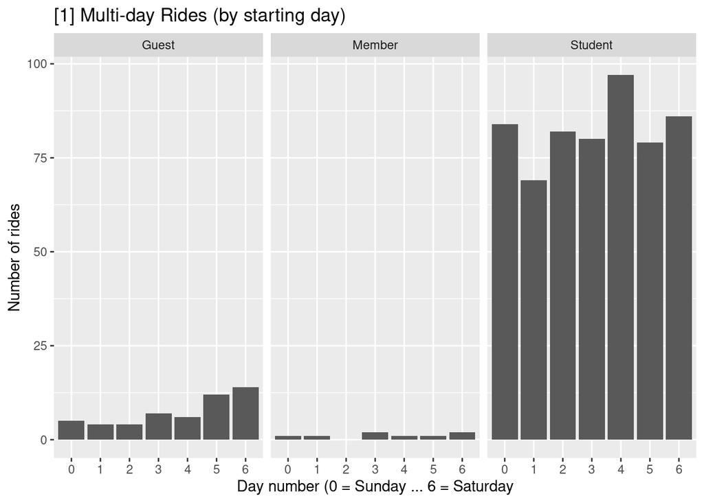

```r
ggplot(day_count_riders_multi, aes(day_number, n)) +
  geom_bar(stat = "identity") +
  facet_wrap(~Rider.Type) +
  theme(axis.text.x = element_text()) +
  labs(
    title = "[1] Multi-day Rides (by starting day) ",
    x = "Day number (0 = Sunday ... 6 = Saturday",
    y = "Number of rides"
  )
```

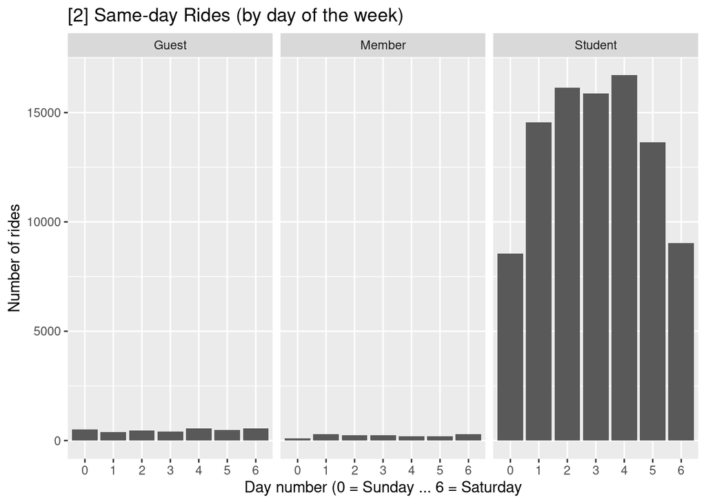

```r
ggplot(day_count_riders_same, aes(day_number, n)) +
  geom_bar(stat = "identity") +
  facet_wrap(~Rider.Type) +
  theme(axis.text.x = element_text()) +
  labs(
    title = "[2] Same-day Rides (by day of the week) ",
    x = "Day number (0 = Sunday ... 6 = Saturday",
    y = "Number of rides"
  )
```

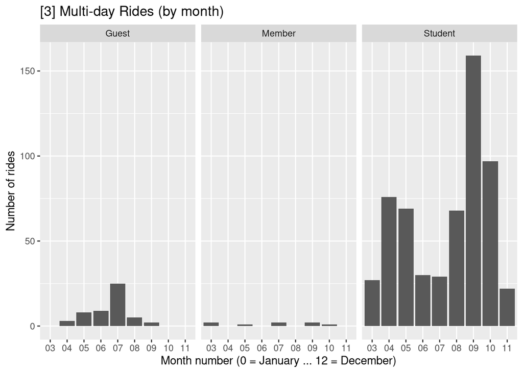

```r
ggplot(month_count_riders_multi, aes(month_number, n)) +
  geom_bar(stat = "identity") +
  facet_wrap(~Rider.Type) +
  theme(axis.text.x = element_text()) +
  labs(
    title = "[3] Multi-day Rides (by month) ",
    x = "Month number (0 = January ... 12 = December)",
    y = "Number of rides"
  )
```

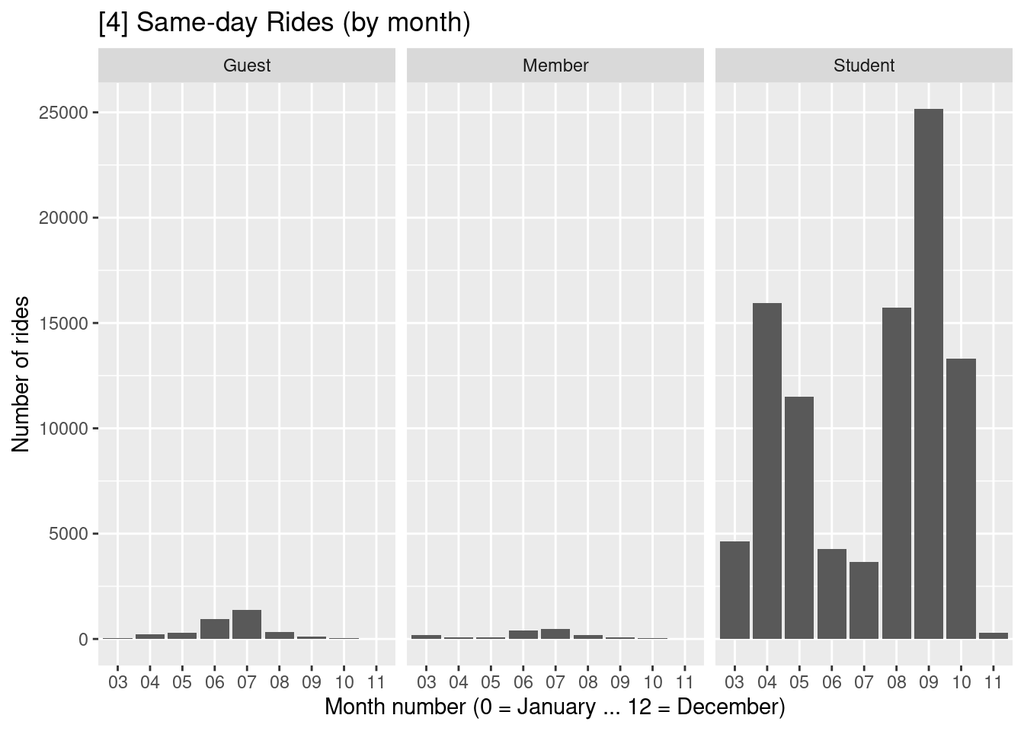

```r
ggplot(month_count_riders_same, aes(month_number, n)) +
  geom_bar(stat = "identity") +
  facet_wrap(~Rider.Type) +
  theme(axis.text.x = element_text()) +
  labs(
    title = "[4] Same-day Rides (by month) ",
    x = "Month number (0 = January ... 12 = December)",
    y = "Number of rides"
  )
```

### Conclusions

Multi-day rides were only 0.6% of the total rides, so the focus of the following discussion will be on the same-day rides. Multi-day rides could be further analyzed, especially if this project progresses to the point of developing a business plan.

The immediate conclusion from analyzing the 2017 data is that *Great Rides Bike Share* is primarily used by students from North Dakota State University. Student rides comprise 95.0 % of both total and same-day rides. This characteristic is very evident in the data visualizations. A possible reason for the high usage by students is that membership in the program is included as part of student fees.

Visualization #2 **Same-day Rides (by day of the week)** shows that students made many more bike rides than the other riders and that more rides are done on weekdays than on weekends, although weekend ridership is still substantial. Visualization #1 **Multi-day Rides (by starting day)** shows a slightly different usage pattern than same-day usage.

Visualization #4 **Same-day Rides (by month)** shows that students made zero rides from December-February while the most rides were made in September. This pattern relates to the peak winter months (Dec-Feb) and the start of the academic year (Sep). Visualization #3 **Multi-day Rides (by month)** shows the same general usage pattern.

### Recommendations

This initial analysis indicates that a bike share operation can be successful in a northern prairie climate. The university students are the primary group of users.

This analysis could be used a starting point to develop a more broadly based proposal that would include information like estimated startup costs, number of bikes and the locations and number of docking stations, management plan, etc. This level of plan would require more analysis of data of other bike share operations and demographic and geographic data for the city of Winnipeg.